# Analysis of Personal Fitness Data

Michael Brown

September 2015

### Description of Experiment

Experiment: Using devices such as Jawbone Up, Nike FuelBand, and Fitbit it is now possible to collect a large amount of data about personal activity relatively inexpensively. This purpose of this experiment is to use data from accelerometers on the belt, forearm, arm, and dumbell of 6 participants and determine if they are performing perform barbell lifts correctly or incorrectly.

Data: Data for this experiment is sourced from the Human Activity Recognition (HAR) project at http://groupware.les.inf.puc-rio.br/har. The data was generated by six young health participants who were asked to perform one set of 10 repetitions of the Unilateral Dumbbell Biceps Curl while wearing a set of accelerometers. The exercise was performed in one of five ways: Class A - exactly according to the specification Class B - throwing the elbows to the front Class C - lifting the dumbbell only halfway Class D - lowering the dumbbell only halfway Class E - throwing the hips to the front

```r
library(caret)
library(splines)
library(parallel)
library(plyr)
require(RCurl)

# Fetch data from Human Activity Recognition project
train.csv <- getURL("https://d396qusza40orc.cloudfront.net/predmachlearn/pml-training.csv")
df.train.data <- read.csv(textConnection(train.csv))

test.csv <- getURL("https://d396qusza40orc.cloudfront.net/predmachlearn/pml-testing.csv")
df.test.data <- as.data.frame(read.csv(textConnection(test.csv)))
```

### Data Exploration

The data from the HAR project consists of a training set and a test set. The training set is made up of 160 variables and 19,622 observations while the testing set consists of 160 variables and 20 observations or prediction instances. The data presents no intuitive pathway to inform an initial model thus we look at the quality of the data and first focus on conditioning it for analysis.

### Data Conditioning

Although the data suggests no intuitive model, the format of the data and the data types themselves suggest several areas for pre-processing:

NAs: looking first at the testing set, all columns with NAs were omitted as they bring no additional value to the analysis and potentially cause the model to fail if it is build on data that doesn’t exist in the testing set. This had the effect of reducing the test data from 160 variables to 53 variables.

Match training and test data: Once the NAs were removed from the testing set, the same columns were removed from the training set in order to avoid modeling on data that was not available for predicting using the test set. This has the added benefit of reducing the amount of data processed during the computationally intensive training process.

Remove non-relevant data: The training data consisted of a variety of metadata including the person conducting the exercise, time stamps and row identifiers. These data were removed as they had no effect on the outcome of the exercise and would otherwise have further complicated the training step.

### Boost GBM Model

Using training data, a model is created using GBM (generalized boosted regression model) package. The results are summarized below.

```r
# Create model
control <- trainControl(method="cv", number=10)
model_gbm <- train(classe~. , data = df.train , method="gbm" , trControl=control ,  verbose = FALSE )
model_gbm$finalModel
```

```
## A gradient boosted model with multinomial loss function.
## 150 iterations were performed.
## There were 52 predictors of which 42 had non-zero influence.
```

### Visualization of Model Variables

The model variables and their relative importance are indicated below. Based on the importance analysis, the model performance could have been further enhanced by deselecting the variables with no explanatory power. Note also that out of the 53 input variables, ~10% have an importance >20 suggesting significant prospect for further enhancement.

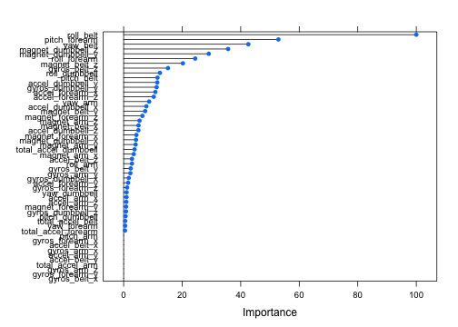

```r
# Visualization
plot(varImp(model_gbm))
```

### Cross Validation and Predicted Error

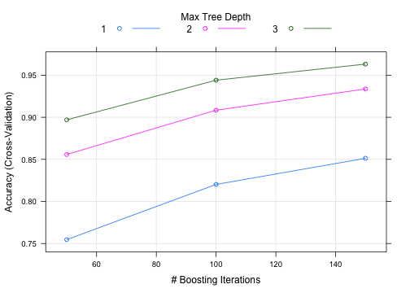

```r
plot(model_gbm)
```

```r
model_gbm
```

```
## Stochastic Gradient Boosting
##
## 16680 samples
##    52 predictor
##     5 classes: 'A', 'B', 'C', 'D', 'E'
##
## No pre-processing
## Resampling: Cross-Validated (10 fold)
## Summary of sample sizes: 15011, 15012, 15013, 15011, 15013, 15012, ...
## Resampling results across tuning parameters:
##
##   interaction.depth  n.trees  Accuracy   Kappa      Accuracy SD
##   1                   50      0.7546137  0.6888870  0.009443745
##   1                  100      0.8202026  0.7724002  0.008440135
##   1                  150      0.8512584  0.8117777  0.006585015
##   2                   50      0.8557533  0.8171968  0.008156253
##   2                  100      0.9083926  0.8840827  0.009068450
##   2                  150      0.9336328  0.9160280  0.005918024
##   3                   50      0.8969415  0.8695252  0.005916967
##   3                  100      0.9440641  0.9292219  0.005581522
##   3                  150      0.9631885  0.9534299  0.004488184
##   Kappa SD
##   0.012077429
##   0.010745992
##   0.008333021
##   0.010407591
##   0.011507262
##   0.007484249
##   0.007522232
##   0.007057761
##   0.005673952
##
## Tuning parameter 'shrinkage' was held constant at a value of 0.1
##
## Tuning parameter 'n.minobsinnode' was held constant at a value of 10
## Accuracy was used to select the optimal model using  the largest value.
## The final values used for the model were n.trees = 150,
##  interaction.depth = 3, shrinkage = 0.1 and n.minobsinnode = 10.
```

### Validation Accuracy

```r
cross_validation_results_boost <- predict(model_gbm , newdata = df.val)
confusionMatrix(df.val$classe , cross_validation_results_boost)
```

```
## Confusion Matrix and Statistics
##
##           Reference
## Prediction   A   B   C   D   E
##          A 826   9   2   0   0
##          B  13 541  15   0   0
##          C   0  17 491   4   1
##          D   0   0  14 467   1
##          E   2   7   4   9 519
##
## Overall Statistics
##
##                Accuracy : 0.9667
##                  95% CI : (0.9596, 0.9729)
##     No Information Rate : 0.2859
##     P-Value [Acc > NIR] : < 2.2e-16
##
##                   Kappa : 0.9579
##  Mcnemar's Test P-Value : NA
##
## Statistics by Class:
##
##                      Class: A Class: B Class: C Class: D Class: E
## Sensitivity            0.9822   0.9425   0.9335   0.9729   0.9962
## Specificity            0.9948   0.9882   0.9909   0.9939   0.9909
## Pos Pred Value         0.9869   0.9508   0.9571   0.9689   0.9593
## Neg Pred Value         0.9929   0.9861   0.9856   0.9947   0.9992
## Prevalence             0.2859   0.1951   0.1788   0.1632   0.1771
## Detection Rate         0.2808   0.1839   0.1669   0.1587   0.1764
## Detection Prevalence   0.2845   0.1934   0.1744   0.1638   0.1839
## Balanced Accuracy      0.9885   0.9653   0.9622   0.9834   0.9935
```

### Prediction

```r
predict.test.gbm <- predict(model_gbm , newdata = df.test )
```

```r
# Produce result files
n = length(predict.test.gbm)
  for(i in 1:n){
    filename = paste0("problem_id_",i,".txt")
    write.table(predict.test.gbm[i],file=filename,quote=FALSE,row.names=FALSE,col.names=FALSE)
    }
```

### Results

The resulting data produced from the boost modeling of the HAR data presented below in order from 1 to 20. On submission to the Coursera Project Page, the results were shown to be 100% correct.

```
##  [1] B A B A A E D B A A B C B A E E A B B B
## Levels: A B C D E
```